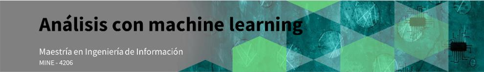

- **Integrante 1:** Santiago Martínez Novoa - 202112020

# Contexto y objetivos.

En el sector hotelero, la cancelación de reservas es un problema significativo que puede tener un impacto negativo en la rentabilidad y la gestión de recursos de un hotel. Las cancelaciones pueden deberse a una variedad de razones, como cambios en los planes de viaje, emergencias personales o simplemente una mejor oferta encontrada en otro lugar. Para los hoteles, esto puede resultar en habitaciones vacías que podrían haber sido vendidas a otros clientes, lo que lleva a una pérdida de ingresos y a una subutilización de recursos como personal, limpieza y mantenimiento.

Además, la cancelación de reservas puede afectar la capacidad del hotel para planificar y gestionar adecuadamente su inventario de habitaciones. Por ejemplo, si un hotel espera que una cierta cantidad de habitaciones estén ocupadas en una date determinada y luego se cancelan muchas reservas, el hotel puede encontrarse con un exceso de disponibilidad de habitaciones que podría haberse asignado de manera más eficiente.

El objetivo principal es desarrollar un modelo predictivo capaz de determinar si una reserva será cancelada o no. Esto permitirá al hotel tomar medidas proactivas, como ofrecer incentivos a los clientes para que no cancelen sus reservas, o gestionar de manera más eficiente la disponibilidad de habitaciones.

Por lo tanto, para poder tomar decisiones en este estudio, se debe presentar:

**Objetivos de desarrollo**:

- Aplicar técnicas de clasificación para construir diferentes modelos predictivos que permitan estimar las cancelaciones del hotel siguiendo el ciclo de machine learning.
- Determinar cuáles son los factores que más inciden en la demanda con base en los datos.

**Datos**: Información obtenida de hotel-booking-cancellation-prediction.

# Entendimiento del negocio.

El conjunto de datos recoge información acerca de reservas de hoteles. Tanto la cantidad de personas en la reserva, número de noches, tipo de habitación, precio promedio, etc... Es importante que revises el diccionario como primer paso para comprender estos datos.

Con apoyo de la organización ha sido posible elaborar el siguiente diccionario de datos:

| ATRIBUTO | DEFINICIÓN |
| --- | --- |
| **Booking_ID** | Identificador único para cada reservación. |
| **number of adults** | Cantidad de adultos incluídos en la reservación. |
| **number if children** | Cantidad de niños incluídos en la reservación. |
| **number of weekend nights** | Número de noches de fin de semana incluídas en la reserva. |
| **number of week nights** | Número de noches entre semana incluídas en la reserva. |
| **type of meal** | Tipo de comida incluída en la reserva. |
| **car parking space** | Indica si se pidió o si se incluía un espacio de parqueadero. |
| **room type** | Tipo de habitación en la reserva. |
| **lead time** | Número de días entre el dia que se realizó la resrerva y el día de reserva. |
| **market segment type** | Tipo de mercado asociado en la reserva. |
| **repeated** | Indica si la reserva es una reserva repetida. |
| **P-C** | Número de reservas canceladas por el usuario antes de la reserva actual. |
| **P-not-C** | Número de reservas cumplidas por el usuario antes de la reserva actual. |
| **average price** | Precio promedio asociado a la reserva. |
| **special request** | Cantidad de peticiones especiales hechas por el usuario. |
| **date of reservation** | Fecha de la reserva. |
| **booking status** | Estado de la reserva (cancelada o no cancelada). |

# Actividades a realizar.

1. Explorar y perfilar los datos utilizando las funciones de la libreria pandas. Recuerda que este paso es muy importante para determinar problemas de calidad (*por ejemplo, valores ausentes y registros duplicados*). Documentar hallazgos (insights) importantes para el negocio.
2. Limpiar y preparar los datos. Justifica las decisiones tomadas basada en la exploración de datos del punto anterior.
3. Realiza el modelamiento de datos en pipelines los algoritmos: Regresión Logística, Support Vector Machine (SVM), Random Forest y Adaboosting. Para cada uno de ellos realiza la busqueda de hiperparámetros y justifica la métrica que vas a usar para el ranking de los modelos.
4. Implementa gráficas que permitan ayudar a interpretar cada una de las clases en cada uno de los modelos.
5. Genera una tabla comparativa e interpreta las métricas de los algoritmos del punto anterior. Al comparar los resultados de los diferentes algoritmos, ¿cuál es el mejor modelo segun el objetivo del negocio y por qué?

**NOTA**: La calificación será sobre notebook ejecutado y cargado en Bloque Neón junto con el archivo HTML.

# Actividades de preparación

## Importación de librerías

```python
#Manejo de datos
import pandas as pd
import numpy as np

#Visualización de datos
import matplotlib.pyplot as plt
import seaborn as sns
%matplotlib inline

#Analisis profundo de datos
from ydata_profiling import ProfileReport

#Entrenamiento del modelo
import sklearn
from sklearn.feature_selection import SelectKBest
from sklearn.feature_selection import chi2, SelectPercentile
from sklearn.impute import SimpleImputer
from sklearn.ensemble import RandomForestClassifier, RandomForestRegressor
from sklearn.linear_model import LinearRegression, LogisticRegression
from sklearn.model_selection import RandomizedSearchCV
from sklearn.model_selection import train_test_split
from sklearn.metrics import mean_squared_error, r2_score, accuracy_score, f1_score, precision_score, recall_score, roc_auc_score,precision_recall_curve
from sklearn.model_selection import GridSearchCV
from sklearn.preprocessing import StandardScaler
from sklearn.preprocessing import OneHotEncoder, OrdinalEncoder, FunctionTransformer
from sklearn.preprocessing import MinMaxScaler
from sklearn.pipeline import Pipeline
from sklearn.tree import plot_tree
from sklearn.svm import SVC, LinearSVC
from sklearn.ensemble import AdaBoostClassifier
from imblearn.over_sampling import SMOTE, SMOTEN


from sklearn.compose import ColumnTransformer, make_column_selector
from sklearn.metrics import classification_report, confusion_matrix, PrecisionRecallDisplay

#Librerías extras
import itertools

from datetime import datetime

print(f"La versión de sklearn es: {sklearn.__version__}")
```

```
La versión de sklearn es: 1.4.1.post1
```

## Carga de los datos

```python
#Cargar los datos del csv ubicado en ./Data/booking.csv
data = pd.read_csv("./Data/booking.csv")

#Mostrar los primeros 5 registros
data.columns

#Para evitar algun tipo de error por espacios en los nombres de las columnas
# se decide reemplazar todos los espacios por _
data.rename(columns=lambda x: x.replace(' ', '_'), inplace=True)

data.head()
```

|  | Booking_ID | number_of_adults | number_of_children | number_of_weekend_nights | number_of_week_nights | type_of_meal | car_parking_space | room_type | lead_time | market_segment_type | repeated | P-C | P-not-C | average_price | special_requests | date_of_reservation | booking_status |
| --- | --- | --- | --- | --- | --- | --- | --- | --- | --- | --- | --- | --- | --- | --- | --- | --- | --- |
| 0 | INN00001 | 1 | 1 | 2 | 5 | Meal Plan 1 | 0 | Room_Type 1 | 224 | Offline | 0 | 0 | 0 | 88.00 | 0 | 10/2/2015 | Not_Canceled |
| 1 | INN00002 | 1 | 0 | 1 | 3 | Not Selected | 0 | Room_Type 1 | 5 | Online | 0 | 0 | 0 | 106.68 | 1 | 11/6/2018 | Not_Canceled |
| 2 | INN00003 | 2 | 1 | 1 | 3 | Meal Plan 1 | 0 | Room_Type 1 | 1 | Online | 0 | 0 | 0 | 50.00 | 0 | 2/28/2018 | Canceled |
| 3 | INN00004 | 1 | 0 | 0 | 2 | Meal Plan 1 | 0 | Room_Type 1 | 211 | Online | 0 | 0 | 0 | 100.00 | 1 | 5/20/2017 | Canceled |
| 4 | INN00005 | 1 | 0 | 1 | 2 | Not Selected | 0 | Room_Type 1 | 48 | Online | 0 | 0 | 0 | 77.00 | 0 | 4/11/2018 | Canceled |

# Separación de la información

## Entrenamientos y test

Cómo el hotel quiere poder predecir que reservas van a ser canceladas y cuales no, se define la variable objetivo

```python
target_feature = 'booking_status'
```

Se separan los datos de entrenamiento y test en una proporción 80% / 20%, además de definir una semilla.

```python
train, test = train_test_split(data, test_size=0.2, random_state=42)
train.head()
```

|  | Booking_ID | number_of_adults | number_of_children | number_of_weekend_nights | number_of_week_nights | type_of_meal | car_parking_space | room_type | lead_time | market_segment_type | repeated | P-C | P-not-C | average_price | special_requests | date_of_reservation | booking_status |
| --- | --- | --- | --- | --- | --- | --- | --- | --- | --- | --- | --- | --- | --- | --- | --- | --- | --- |
| 387 | INN00388 | 3 | 0 | 1 | 3 | Meal Plan 1 | 0 | Room_Type 4 | 155 | Online | 0 | 0 | 0 | 115.6 | 1 | 12/26/2018 | Canceled |
| 7768 | INN07769 | 1 | 0 | 2 | 2 | Meal Plan 1 | 0 | Room_Type 4 | 48 | Online | 0 | 0 | 0 | 149.4 | 0 | 9/18/2018 | Canceled |
| 11792 | INN11793 | 2 | 0 | 1 | 2 | Meal Plan 1 | 0 | Room_Type 1 | 305 | Offline | 0 | 0 | 0 | 89.0 | 0 | 11/4/2018 | Canceled |
| 7978 | INN07979 | 1 | 0 | 0 | 2 | Meal Plan 1 | 0 | Room_Type 1 | 102 | Online | 0 | 0 | 0 | 86.4 | 2 | 12/6/2018 | Canceled |
| 10670 | INN10671 | 2 | 2 | 1 | 2 | Meal Plan 1 | 0 | Room_Type 6 | 9 | Online | 0 | 0 | 0 | 221.0 | 0 | 6/10/2018 | Canceled |

A continuación la distribución de los datos tras las separación de la información.

```python
train_count = train.shape[0]
test_count = test.shape[0]

print("-------------------SEPARACIÓN DE LA INFORMACIÓN-------------------")
print(f"-> Train: {train_count:,}")
print(f"-> Test: {test_count:,}")
```

```
-------------------SEPARACIÓN DE LA INFORMACIÓN-------------------
-> Train: 29,028
-> Test: 7,257
```